# Simple <em>varrank</em> example

**What is the package design for?**

The two main problems addressed by this package are **selection of the most representative variable** within a group of variables of interest (i.e. dimension reduction) and **variable ranking** with respect to a set of features of interest.

**How does it work?**

The *varrank* R package takes a named dataset as input. It transforms the continuous variables into categorical ones using discretization rules. Then a *varrank* analysis sequentially compares relevance with redundancy. The final rank is based on the measure of this score.

**What are the R package functionalities?**

The workhorse of the R package is the *varrank()* function. It computes the rank of variables and it returns a varrank class object. This object can be summarized with a comprehensive verbal description or a plot.

**What is the structure of this document?**

We first illustrate the package with a simple example. In a second step we compare the output of the main function *varrank()* with alternative approaches. Then some details are provided. For a full description of the technical details we refer to the original publication [@gk2018].

# Simple *varrank* example

The package is available through [CRAN](https://CRAN.R-project.org/package=varrank) and can be installed directly in R:

```r
install.packages("varrank")
```

Once installed, the *varrank* R package can be loaded using:

```r
library(varrank)
```

Let us start with a ranking example from the *mlbench* R package [@leischmlbench]. The *PimaIndiansDiabetes* dataset contains 768 observations on 9 clinical variables. To run the *varrank()* function, one needs to choose a score function model (“battiti”, “kwak”, “peng”, “estevez”), a discretization method (see discretization for details) and an algorithm scheme (“forward”, “backward”).

For the first search, it is advised to use either “peng” (faster) or “estevez” (more reliable but much slower for large datasets) and, in case the number of variables is large (>100), restrict the “forward” search to “n.var = 100.” The progress bar will give you an idea of the remaining run time.

```r
data(PimaIndiansDiabetes, package = "mlbench")
varrank.PimaIndiansDiabetes <- varrank(data.df = PimaIndiansDiabetes, method = "estevez", variable.important = "diabetes", discretization.method = "sturges", algorithm = "forward", scheme="mid", verbose = FALSE)

summary(varrank.PimaIndiansDiabetes)
```

```
#> Number of variables ranked: 8
#> forward search using estevez method
#> (mid scheme)
#>
#> Ordered variables (decreasing importance):
#>        glucose mass   age pedigree insulin pregnant pressure triceps
#> Scores   0.187 0.04 0.036   -0.005  -0.013   -0.008   -0.014      NA
#>
#>  ---
#>
#>  Matrix of scores:
#>          glucose   mass    age pedigree insulin pregnant pressure triceps
#> glucose    0.187
#> mass       0.092   0.04
#> age        0.085  0.021  0.036
#> pedigree   0.031  0.007 -0.005   -0.005
#> insulin    0.029 -0.041 -0.024   -0.015  -0.013
#> pregnant   0.044  0.013  0.017    -0.03  -0.016   -0.008
#> pressure   0.024 -0.009 -0.021   -0.024  -0.019   -0.015   -0.014
#> triceps    0.034  0.009 -0.046   -0.034  -0.024   -0.035    -0.02
```

The function *varrank()* returns a list with multiple entries: “names.selected” and “distance.m”. If `algorithm = "forward"`, “names.selected” contains an ordered list of the variable names in **decreasing** order of importance relative to the set in “variable.important” and, for a backward search, the list is in increasing order of importance. The scheme of comparison between relevance and redundance should be set to “mid” (Mutual Information Difference) or “miq” (Mutual Information Quotient). In order to visually assess *varrank()* output, one can plot it:

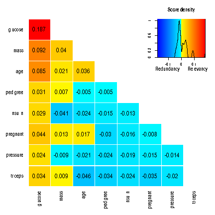

```r
plot(varrank.PimaIndiansDiabetes)
```

Basically, the *varrank()* function sequentially compares the relevancy/redundancy balance of information across the set of variables. There is a legend containing the color code (cold blue for redundancy, hot red for relevancy) and the distribution of the scores. The columns of the triangular matrix contain the scores at each selection step. The variable selected at each step is the one with the highest score (the variables are ordered in the plot). The scores at selection can thus be read from the diagonal. A negative score indicates a redundancy final trade of information and a positive score indicates a relevancy final trade of information.

## Comparison with other R packages

### Caret

Here is the output of the *caret* R package [@kuhn2014caret] applied to the same *PimaIndiansDiabetes* dataset. *caret* allows one to perform a model-free variable selection search. In such a case, the importance of each predictor is evaluated individually using a filter approach.

```r
library(caret)
library(e1071)
# prepare training scheme
control <- trainControl(method = "repeatedcv", number = 10, repeats = 3)
# train the model
model <- train(diabetes~., data = PimaIndiansDiabetes, method = "lvq", preProcess = "scale", trControl = control)
# estimate variable importance
importance <- varImp(model, useModel = FALSE)
# summarize importance
print(importance)
```

```
#> ROC curve variable importance
#>
#>          Importance
#> glucose       100.0
#> mass           59.8
#> age            59.6
#> pregnant       32.6
#> pedigree       27.3
#> pressure       19.4
#> triceps         6.3
#> insulin         0.0
```

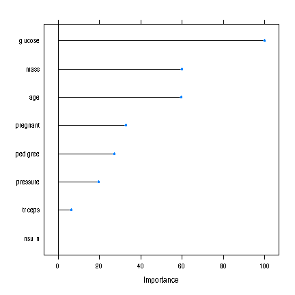

```r
# plot importance
plot(importance)
```

### R Package *Boruta*

An alternative for variable selection is the *Boruta* R package [@kursa2010feature]. This compares the original attributes' importance with the importance achieved by random, estimated using their permuted copies in the Random Forest method. The *Boruta* output from the analysis of the same dataset is as follows.

```r
library(Boruta)
out.boruta <- Boruta(diabetes~., data = PimaIndiansDiabetes)
print(out.boruta)
```

```
#> Boruta performed 99 iterations in 4.96 secs.
#>  7 attributes confirmed important: age, glucose, insulin, mass,
#> pedigree and 2 more;
#>  No attributes deemed unimportant.
#>  1 tentative attributes left: pressure;
```

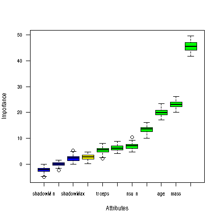

```r
plot(out.boruta, cex.axis = 0.8, las=1)
```

### R Package varSelRF

*varSelRF* [@diaz2007genesrf] is a random forest-based R package that performs variable ranking. The output of the same analysis is as follows.

```r
library(varSelRF)

rf <- randomForest(diabetes~., data = PimaIndiansDiabetes, ntree = 200, importance = TRUE)
rf.rvi <- randomVarImpsRF(xdata = PimaIndiansDiabetes[, 1:8], Class = PimaIndiansDiabetes[, 9], forest = rf, numrandom = 20, usingCluster = FALSE)
```

```
#>
#>  Obtaining random importances ....................
```

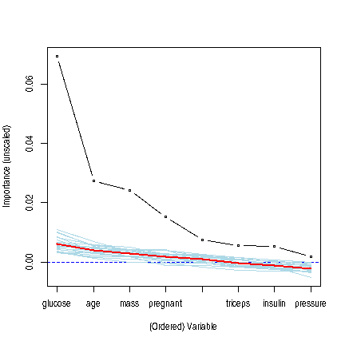

```r
randomVarImpsRFplot(rf.rvi, rf, show.var.names = TRUE, cexPoint = 0.3,cex.axis=0.3)
```

### FSelector

The *FSelector* R package [@romanski2016fselector] contains a large number of implemented techniques for generating rank weights for features. Below is an example based on an entropy-based filter using information gain applied to the same example.

```r
library(FSelector)
weights <- information.gain(diabetes~., data = PimaIndiansDiabetes)
row.names(weights)[order(weights$attr_importance, decreasing = TRUE)]
```

```
#> [1] "glucose"  "mass"     "age"      "insulin"  "pregnant" "pedigree" "pressure"
#> [8] "triceps"
```

# Underlying Theory of *varrank*

## Information theory metrics

The *varrank* R package is based on the estimation of information theory metrics, namely, the *entropy* and the *mututal information*.

Intuitivelly, the *entropy* is defined as the average amount of information produced by a stochastic source of data. The *mutual information* is defined as the mutual dependence between the two variables.

## Entropy from observational data

Formally, for a continuous random variable \(X\) with probability density function \(P(X)\) the entropy \(\text{H}(X)\) is defined as [see @cover2012elements for details]

\[ \text{H}(X) = \textbf{E} [ - \log{P(X)} ]. \]

The entropy \(\text{H}(X)\) of a discrete random variable \(X\) is defined as [see @cover2012elements for details] \[ \text{H}(X) = \sum^{N}_{n = 1} P(x_n) \log{P(x_n)}, \] where \(N\) is the number of states of the random variable \(X\).

We now illustrate the calculation of entropy for some simple cases and give the true/theoretical values, as well.

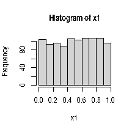

```r
### 1D example ####
# sample from continuous uniform distribution
x1 = runif(1000)
hist(x1, xlim = c(0, 1))
```

```r
#True entropy value: H(X) = log(1000) = 6.91
entropy.data(freqs.table = table(discretization(data.df = data.frame(x1), discretization.method = "rice", freq = FALSE)))
```

```
#> [1] 4.23
```

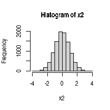

```r
# sample from a non-uniform distribution
x2 = rnorm(n = 10000, mean = 0, sd = 1)
hist(x2)
```

```r
#differential entropy: H(x) = log(1*sqrt(2*pi*exp(1))) = 1.42
entropy.data(freqs.table = table(discretization(data.df = data.frame(x2), discretization.method = "sturges", freq = FALSE)))
```

```
#> [1] 2.8
```

```r
### 2D example ####
# two independent random variables
x1 <- runif(100)
x2 <- runif(100)


## Theoretical entropy: 2*log(100) = 9.21
entropy.data(freqs.table = table(discretization(data.df = data.frame(x1, x2), discretization.method = "sturges", freq = FALSE)))
```

```
#> [1] 4.92
```

## Mutual information from observational data

```r
# mutual information for 2 uniform random variables
x1 <- runif(10000)
x2 <- runif(10000)

# approximately zero
mi.data(X = x1, Y = x2, discretization.method = "kmeans")
```

```
#> [1] 0.00618
```

```r
# MI computed directely
mi.data(X = x2, Y = x2, discretization.method = "kmeans")
```

```
#> [1] 3.45
```

```r
# MI computed with entropies:
##MI(x,y) = H(x)+H(y)-H(x, y) for x=y;
##MI(x,x) = 2 * H(x) - H(x,x)
2 * entropy.data(freqs.table = table(discretization(data.df = data.frame(x2), discretization.method = "kmeans", freq = FALSE))) - entropy.data(freqs.table = table(discretization(data.df = data.frame(x2, x2), discretization.method = "kmeans", freq = FALSE)))
```

```
#> [1] 3.45
```

# Variables ranking/feature ranking

This equation is called the mRMRe equation. Model names and their corresponding functions \(\alpha\) and parameters \(\beta\) are listed below in historical order of publication:

1. \(\beta>0\) is a user defined parameter and \(\alpha(f_i,f_s,\textbf{C})=1\), named mutual information feature selector (MIFS). This method is called \textit{biattiti} in varrank and presented in @battiti1994using.
2. \(\beta>0\) is a user defined parameter and \(\alpha(f_i,f_s,\textbf{C})={\text{MI}(f_s;\textbf{C})}/{\text{H}(f_s)}\), named MIFS-U. This method is called \textit{kwak} in varrank and presented in @kwak2002input.
3. \(\beta={1}/{|\textbf{S}|}\) and \(\alpha(f_i,f_s,\textbf{C})=1\), which is named min-redundancy max-relevance (mRMR). This method is called \textit{peng} in varrank and presented in @peng2005feature.
4. \(\beta={1}/{|\textbf{S}|}\) and \(\alpha(f_i,f_s,\textbf{C})={1}/{\text{min}(\text{H}(f_i),\text{H}(f_s))}\) named Normalized MIFS (NMIFS). This method is called \textit{estevez} in varrank and presented in @estevez2009normalized.

The two terms on the right-hand side of the definition of the local score function above are local proxies for the relevance and the redundancy, respectively. Redundancy is a penalty included to avoid selecting features highly correlated with previously selected ones. Local proxies are needed because computing the joint MI between high dimensional vectors is computationally expensive. The function \(\alpha\) and the parameter \(\beta\) attempt to balance both terms to the same scale. In @peng2005feature and @estevez2009normalized, the ratio of comparison is adaptively chosen as \(\beta = 1/{|S|}\) to control the second term, which is a cumulative sum and increases quickly as the cardinality of \(\textbf{S}\) increases. The function \(\alpha\) tends to normalize the right side. One can remark that \(0 \leq \text{MI}(f_i;f_s) \leq \min(\text{H}(f_i), \text{H}(f_s))\).

## Software implementation

A common characteristic of data from systems epidemiology is that it contains both discrete and continuous variables. Thus, a common popular and efficient choice for computing information metrics is to discretize the continuous variables and then deal with only discrete variables. A recent survey of discretization techniques can be found in @garcia2013survey. Some static univariate unsupervised splitting approaches are implemented in the package. In the current implementation, one can give a user-defined number of bins (not recommended) or use a histogram-based approach. Popular choices for the latter are: Cencov's rule [@cencov1962estimation], Freedman-Diaconis' rule [@freedman1981histogram], Scott's rule [@scott], Sturges' rule [@sturges], Doane's formula [@doane] and Rice's rule. The MI is estimated through entropy using mRMRe equation and the count of the empirical frequencies. This is a plug-in estimator. Another approach is to use a clustering approach with the elbow method to determine the optimal number of clusters. Finally, one very popular MI estimation compatible only with continuous variables is based on nearest neighbors [@kraskov2004estimating]. The workhorse of *varrank* is the forward/backward implementation of mRMRe equation. The sequential forward variable ranking algorithm is described in [@gk2018].

## Software functionalities

The package *varrank* exploits the **object oriented functionalities** of R through the S3 class. The function *varrank()* returns an object of class *varrank*, a list with multiple entries. At present, three S3 methods have been implemented: the print method displaying a condensed output, the summary method displaying the full output and a plot method. The plot method is an adapted version of *heatmap.2()* from the R package *gplots*.

```r
output <- varrank(data.df = PimaIndiansDiabetes, method = "battiti", variable.important = "diabetes", discretization.method = "sturges", ratio = 0.6, algorithm = "forward", scheme="mid", verbose = FALSE)

##print
output
```

```
#> [1] "glucose"  "mass"     "pedigree" "age"      "insulin"  "pressure" "pregnant"
#> [8] "triceps"
```

```r
##summary
summary(output)
```

```
#> Number of variables ranked: 8
#> forward search using battiti method
#> (mid scheme)
#>
#> Ordered variables (decreasing importance):
#>        glucose  mass pedigree    age insulin pressure pregnant triceps
#> Scores   0.187 0.046   -0.032 -0.068  -0.185   -0.268   -0.399      NA
#>
#>  ---
#>
#>  Matrix of scores:
#>          glucose   mass pedigree    age insulin pressure pregnant triceps
#> glucose    0.187
#> mass       0.092  0.046
#> pedigree   0.031  0.002   -0.032
#> age        0.085  0.008   -0.037 -0.068
#> insulin    0.029 -0.061   -0.106 -0.149  -0.185
#> pressure   0.024 -0.026   -0.111  -0.15  -0.232   -0.268
#> pregnant   0.044 -0.003   -0.037 -0.068  -0.317   -0.341   -0.399
#> triceps    0.034  0.002   -0.173 -0.212  -0.266   -0.407   -0.479
```

The plot display depends on whether the algorithm is run in a forward search or backward search.

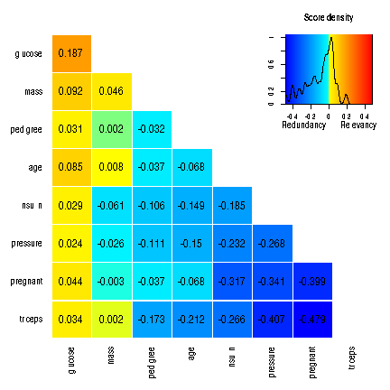

```r
output <- varrank(data.df = PimaIndiansDiabetes, method = "battiti", variable.important = "diabetes", discretization.method = "sturges", ratio = 0.6, algorithm = "forward", scheme="mid", verbose = FALSE)

plot(output)
```

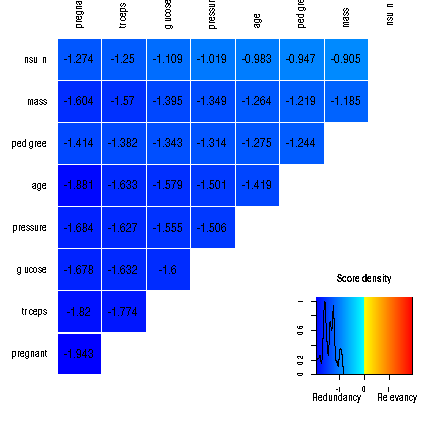

```r
output<-varrank(data.df = PimaIndiansDiabetes, method = "battiti", variable.important = "diabetes", discretization.method = "sturges", ratio = 0.6, algorithm = "backward",scheme="mid", verbose = FALSE)

plot(output)
```

## Examples based on different datasets

Below are some examples of the *varrank* methodology applied to classical R datasets.

### Swiss Fertility and Socioeconomic Indicators (1888) Data

The swiss fertility dataset [@R-Core-Team:2017aa] consists of six continuous variables with 47 observations.

Exploratory data analysis:

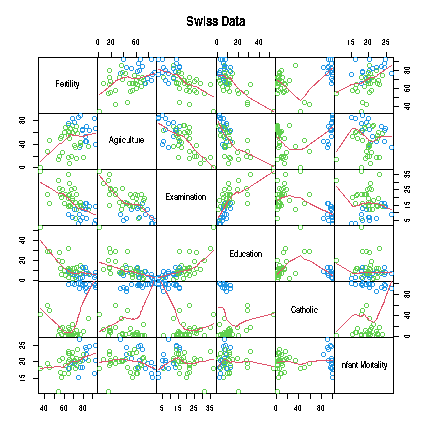

```r
pairs(swiss, panel = panel.smooth, main = "Swiss Data",
      col = 3 + (swiss$Catholic > 80), gap = 0)
```

```r
summary(lm(Fertility ~ . , data = swiss))
```

```
#>
#> Call:
#> lm(formula = Fertility ~ ., data = swiss)
#>
#> Residuals:
#>     Min      1Q  Median      3Q     Max
#> -15.274  -5.262   0.503   4.120  15.321
#>
#> Coefficients:
#>                  Estimate Std. Error t value Pr(>|t|)
#> (Intercept)       66.9152    10.7060    6.25  1.9e-07 ***
#> Agriculture       -0.1721     0.0703   -2.45   0.0187 *
#> Examination       -0.2580     0.2539   -1.02   0.3155
#> Education         -0.8709     0.1830   -4.76  2.4e-05 ***
#> Catholic           0.1041     0.0353    2.95   0.0052 **
#> Infant.Mortality   1.0770     0.3817    2.82   0.0073 **
#> ---
#> Signif. codes:  0 '***' 0.001 '**' 0.01 '*' 0.05 '.' 0.1 ' ' 1
#>
#> Residual standard error: 7.17 on 41 degrees of freedom
#> Multiple R-squared:  0.707,  Adjusted R-squared:  0.671
#> F-statistic: 19.8 on 5 and 41 DF,  p-value: 5.59e-10
```

Forward *varrank* analysis:

```r
swiss.varrank <- varrank(data.df = swiss, method = "estevez", variable.important = "Fertility", discretization.method = "sturges", algorithm = "forward", scheme = "mid", verbose = FALSE)
swiss.varrank
```

```
#> [1] "Catholic"         "Infant.Mortality" "Education"        "Examination"
#> [5] "Agriculture"
```

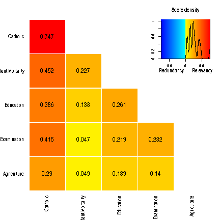

```r
plot(swiss.varrank)
```

### Longley

This is a data frame with seven continuous economical variables from the US, observed yearly from 1947 to 1962. This dataset is known to be highly collinear [@R-Core-Team:2017aa].

The exploratory data analysis:

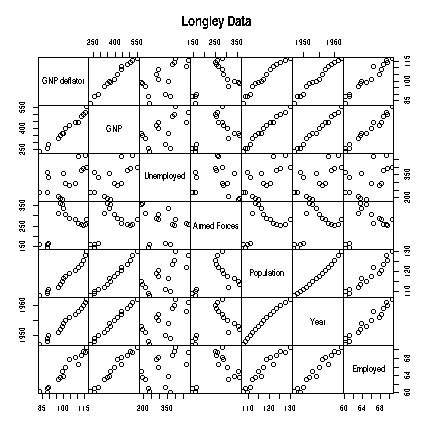

```r
pairs(longley, main = "Longley Data", gap = 0)
```

```r
summary(fm1 <- lm(Employed ~ ., data = longley))
```

```
#>
#> Call:
#> lm(formula = Employed ~ ., data = longley)
#>
#> Residuals:
#>     Min      1Q  Median      3Q     Max
#> -0.4101 -0.1577 -0.0282  0.1016  0.4554
#>
#> Coefficients:
#>               Estimate Std. Error t value Pr(>|t|)
#> (Intercept)  -3.48e+03   8.90e+02   -3.91  0.00356 **
#> GNP.deflator  1.51e-02   8.49e-02    0.18  0.86314
#> GNP          -3.58e-02   3.35e-02   -1.07  0.31268
#> Unemployed   -2.02e-02   4.88e-03   -4.14  0.00254 **
#> Armed.Forces -1.03e-02   2.14e-03   -4.82  0.00094 ***
#> Population   -5.11e-02   2.26e-01   -0.23  0.82621
#> Year          1.83e+00   4.55e-01    4.02  0.00304 **
#> ---
#> Signif. codes:  0 '***' 0.001 '**' 0.01 '*' 0.05 '.' 0.1 ' ' 1
#>
#> Residual standard error: 0.305 on 9 degrees of freedom
#> Multiple R-squared:  0.995,  Adjusted R-squared:  0.992
#> F-statistic:  330 on 6 and 9 DF,  p-value: 4.98e-10
```

Forward *varrank* analysis:

```r
longley.varrank <- varrank(data.df = longley, method = "estevez", variable.important = "Employed", discretization.method = "sturges", algorithm = "forward", scheme = "mid", verbose = FALSE)
longley.varrank
```

```
#> [1] "GNP"          "Armed.Forces" "Population"   "GNP.deflator" "Year"
#> [6] "Unemployed"
```

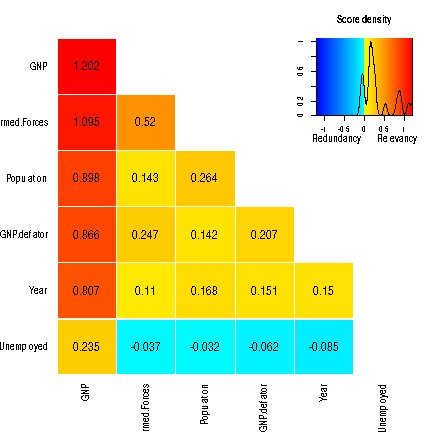

```r
plot(longley.varrank)
```

### Air Quality dataset

Exploratory data analysis:

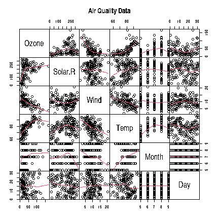

```r
pairs(airquality, panel = panel.smooth, main = "Air Quality Data", gap = 0)
```

Forward *varrank* analysis

```r
airquality.varrank <- varrank(data.df = (data.frame(lapply(airquality[complete.cases(airquality), ], as.numeric))), method = "estevez", variable.important = "Ozone", discretization.method = "sturges", algorithm = "forward", scheme = "mid", verbose = FALSE)
airquality.varrank
```

```
#> [1] "Temp"    "Wind"    "Day"     "Solar.R" "Month"
```

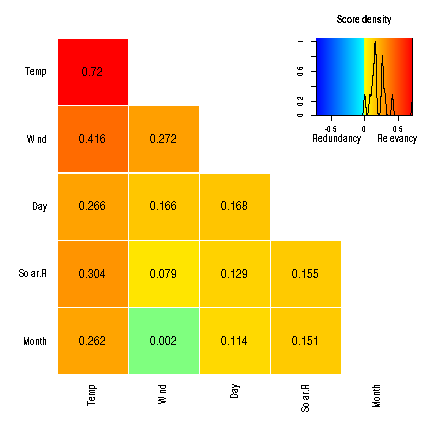

```r
plot(airquality.varrank)
```

### Airbags and other influences on accident fatalities

This is US data (1997-2002) from police-reported car crashes in which there was a harmful event (people or property) and from which at least one vehicle was towed. This dataset [@maindonald2014daag] contains 15 variables with 26'217 observations. The *varrank* forward search is performed using “peng” model.

```r
data(nassCDS)

nassCDS.varrank <- varrank(data.df = nassCDS, method = "peng", variable.important = "dead", discretization.method = "sturges", algorithm = "forward", scheme = "mid", verbose = FALSE)
nassCDS.varrank
```

```
#>  [1] "injSeverity" "frontal"     "ageOFocc"    "yearacc"     "dvcat"
#>  [6] "occRole"     "weight"      "seatbelt"    "sex"         "airbag"
#> [11] "deploy"      "yearVeh"     "abcat"       "caseid"
```

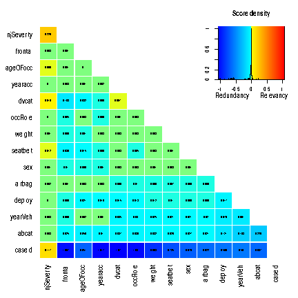

```r
plot(nassCDS.varrank, notecex = 0.5)
```